# Species distribution maps for West Gippsland 2021-2022

DG Nicholls

01 November 2022 at 13:23

## Introduction

The Bushlands of Western Port between Nyora and Granville were surveyed with camera trapping byu the Southern Brown Bandicoot Regional Recvodery Group between 2012 to April 2022. The report, **Report to Investor Bass Coast Camera Trapping** included a map showing the distribution of the Southern Brown Bandicoot but no other species. This paper address that short coming with maps of the species where there are sufficient observations.

Interactive maps are created for species of interest. The observations of mammals species are mapped with a selection of the bird and two reptiles. The base map can be selected (using the layers icon on the left.).

# Methods

### Data sets

We use the `Stations.new1` CTtable. This has the attributes of the `Stations` plus six extra appended attributes, namely the Mga coordinates, Latitude-Longitude (GDA94 decimal degrees), and two fields that measure the difference between the manually entered coordinates and the the coordinates derived programatically from the GIS file.

The `camtrapR` record table is here as the `Species` R data frame.

### Work flow

For the pdf maps

- access R_CENTRAL_DATA and _UTILITIES
- get `Stations.new1`
  - subset for the West Gippsland stations (excluding the pre 2020 March records )
  - identify the remaining records where there are no coordinates
- merge `Species` and the selected West Gippsland Stations to add location coordinates to the Species table
- identify the list of species, `species_available`, some 70 species
- make a list of a selection; common mammals, interesting species, a few birds, reptiles; `species_selected`
- prepare a base map with sf package and ggplot, `bmap`. Not used instead use `sp`
- with `sp` change locality, llpg and PVres into R objects
- with a for loop, cycle through the `species_selected`
- using ggplot to produce a PDF file the species records on the base map.

For the interactive maps (used here)

- set eval = FALSE for PDF maps
- remove existing R object
- set `shapefilename`
- call `camtrapR::detectionMaps` to create shapefile
- with `mapview` display shalefile

# Species frequency

Markers or quality control pointers (e.g. first, start) and inadequately identified records are removed. N.B. This repeats script in 4_Summary_Tables_All. We have to decide if these scripts are run in order as a set, or each script will run independently. Here, I am assuming the script will run independently.

## Base Map with `sf`

Use the modern package `sf`.

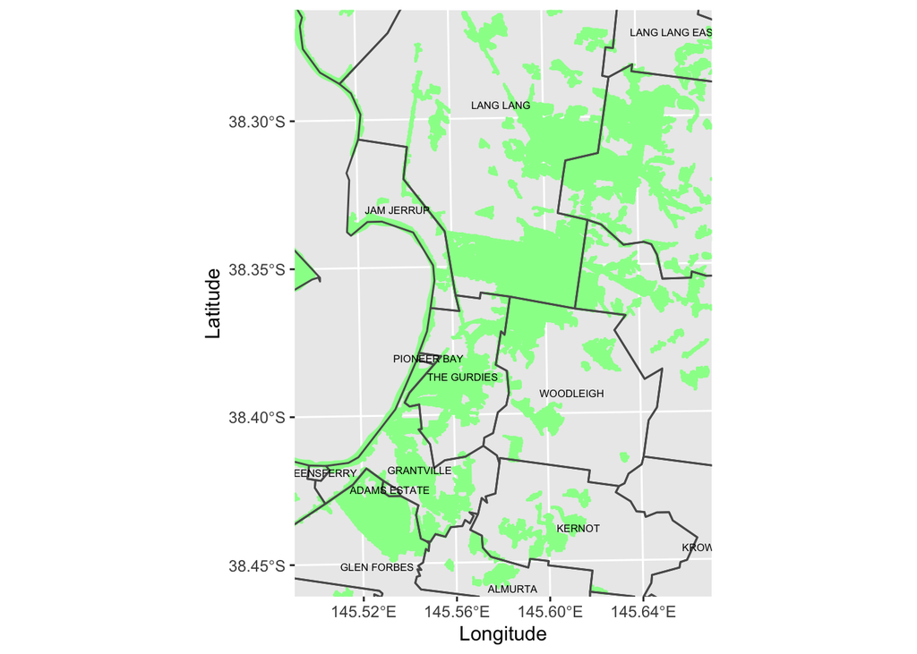

## Species maps

The maps include locality (as defined by DELWP), conservation reserves and trapping stations (black dot) and species present (red square).

### List of species

List of Species, by taxa

| Taxon | Species |
| --- | --- |
| Monotreme | Short-beaked Echidna |
| Marsupial | Agile Antechinus |
|  | Dusky Antechinus |
|  | Southern Brown Bandicoot |
|  | Long-nosed Bandicoot |
|  | Common Wombat |
|  | Koala |
|  | Mountain Brushtail Possum |
|  | Common Brushtail Possum |
|  | Sugar Glider |
|  | Common Ringtail Possum |
|  | Eastern Grey Kangaroo |
|  | Black Wallaby |
| Placental | Bush Rat |
|  | Swamp Rat |
|  | Black Rat |
|  | deer |
|  | Red Fox |
|  | Cat |
| Aves | Painted Button-quail |
|  | Bassian Thrush |
|  | Eastern WhipBird |
| Reptile | Lace Monitor |
|  | Blotched Blue-tongue Lizard |

## Map Southern Brown Bandicoot with `mapview`

Use the interactive map. At the top left, the plus/minus icons zoom. The layers icon, drops down to offer different background maps. In the bottom left, the title restores the default extent to the map.

[interactive chart not shown]

## Map Lace Monitor with `mapview`

[interactive chart not shown]

## Map Red Fox with `mapview`

[interactive chart not shown]

## Map Agile Antechinus with `mapview`

[interactive chart not shown]